# Exploratory Analysis of Ford GoBike Data

## Introduction

Here I will be conducting an explanatory analysis of the data although first I'll have to clean it up and do some organising.

```python
# import all packages and set plots to be embedded inline
import numpy as np
import pandas as pd
import matplotlib.pyplot as plt
import seaborn as sb

%matplotlib inline
```

## Preliminary Wrangling

### Gathering Data

```python
# loading in the dataset from the csv file.
df = pd.read_csv('201902-fordgobike-tripdata.csv')
```

### Assessment

```python
# Quick check of the read data.
df.head(10)
```

|  | duration_sec | start_time | end_time | start_station_id | start_station_name | start_station_latitude | start_station_longitude | end_station_id | end_station_name | end_station_latitude | end_station_longitude | bike_id | user_type | member_birth_year | member_gender | bike_share_for_all_trip |
| --- | --- | --- | --- | --- | --- | --- | --- | --- | --- | --- | --- | --- | --- | --- | --- | --- |
| 0 | 52185 | 2019-02-28 17:32:10.1450 | 2019-03-01 08:01:55.9750 | 21.0 | Montgomery St BART Station (Market St at 2nd St) | 37.789625 | -122.400811 | 13.0 | Commercial St at Montgomery St | 37.794231 | -122.402923 | 4902 | Customer | 1984.0 | Male | No |
| 1 | 42521 | 2019-02-28 18:53:21.7890 | 2019-03-01 06:42:03.0560 | 23.0 | The Embarcadero at Steuart St | 37.791464 | -122.391034 | 81.0 | Berry St at 4th St | 37.775880 | -122.393170 | 2535 | Customer | NaN | NaN | No |
| 2 | 61854 | 2019-02-28 12:13:13.2180 | 2019-03-01 05:24:08.1460 | 86.0 | Market St at Dolores St | 37.769305 | -122.426826 | 3.0 | Powell St BART Station (Market St at 4th St) | 37.786375 | -122.404904 | 5905 | Customer | 1972.0 | Male | No |
| 3 | 36490 | 2019-02-28 17:54:26.0100 | 2019-03-01 04:02:36.8420 | 375.0 | Grove St at Masonic Ave | 37.774836 | -122.446546 | 70.0 | Central Ave at Fell St | 37.773311 | -122.444293 | 6638 | Subscriber | 1989.0 | Other | No |
| 4 | 1585 | 2019-02-28 23:54:18.5490 | 2019-03-01 00:20:44.0740 | 7.0 | Frank H Ogawa Plaza | 37.804562 | -122.271738 | 222.0 | 10th Ave at E 15th St | 37.792714 | -122.248780 | 4898 | Subscriber | 1974.0 | Male | Yes |
| 5 | 1793 | 2019-02-28 23:49:58.6320 | 2019-03-01 00:19:51.7600 | 93.0 | 4th St at Mission Bay Blvd S | 37.770407 | -122.391198 | 323.0 | Broadway at Kearny | 37.798014 | -122.405950 | 5200 | Subscriber | 1959.0 | Male | No |
| 6 | 1147 | 2019-02-28 23:55:35.1040 | 2019-03-01 00:14:42.5880 | 300.0 | Palm St at Willow St | 37.317298 | -121.884995 | 312.0 | San Jose Diridon Station | 37.329732 | -121.901782 | 3803 | Subscriber | 1983.0 | Female | No |
| 7 | 1615 | 2019-02-28 23:41:06.7660 | 2019-03-01 00:08:02.7560 | 10.0 | Washington St at Kearny St | 37.795393 | -122.404770 | 127.0 | Valencia St at 21st St | 37.756708 | -122.421025 | 6329 | Subscriber | 1989.0 | Male | No |
| 8 | 1570 | 2019-02-28 23:41:48.7900 | 2019-03-01 00:07:59.7150 | 10.0 | Washington St at Kearny St | 37.795393 | -122.404770 | 127.0 | Valencia St at 21st St | 37.756708 | -122.421025 | 6548 | Subscriber | 1988.0 | Other | No |
| 9 | 1049 | 2019-02-28 23:49:47.6990 | 2019-03-01 00:07:17.0250 | 19.0 | Post St at Kearny St | 37.788975 | -122.403452 | 121.0 | Mission Playground | 37.759210 | -122.421339 | 6488 | Subscriber | 1992.0 | Male | No |

```python
# High Level look at our data
df.info()
```

```
<class 'pandas.core.frame.DataFrame'>
RangeIndex: 183412 entries, 0 to 183411
Data columns (total 16 columns):
 #   Column                   Non-Null Count   Dtype
---  ------                   --------------   -----
 0   duration_sec             183412 non-null  int64
 1   start_time               183412 non-null  object
 2   end_time                 183412 non-null  object
 3   start_station_id         183215 non-null  float64
 4   start_station_name       183215 non-null  object
 5   start_station_latitude   183412 non-null  float64
 6   start_station_longitude  183412 non-null  float64
 7   end_station_id           183215 non-null  float64
 8   end_station_name         183215 non-null  object
 9   end_station_latitude     183412 non-null  float64
 10  end_station_longitude    183412 non-null  float64
 11  bike_id                  183412 non-null  int64
 12  user_type                183412 non-null  object
 13  member_birth_year        175147 non-null  float64
 14  member_gender            175147 non-null  object
 15  bike_share_for_all_trip  183412 non-null  object
dtypes: float64(7), int64(2), object(7)
memory usage: 22.4+ MB
```

```python
# Check for values
df.notnull().sum()
```

```
duration_sec               183412
start_time                 183412
end_time                   183412
start_station_id           183215
start_station_name         183215
start_station_latitude     183412
start_station_longitude    183412
end_station_id             183215
end_station_name           183215
end_station_latitude       183412
end_station_longitude      183412
bike_id                    183412
user_type                  183412
member_birth_year          175147
member_gender              175147
bike_share_for_all_trip    183412
dtype: int64
```

```python
# Checking for unique values
df.nunique()
```

```
duration_sec                 4752
start_time                 183401
end_time                   183397
start_station_id              329
start_station_name            329
start_station_latitude        334
start_station_longitude       335
end_station_id                329
end_station_name              329
end_station_latitude          335
end_station_longitude         335
bike_id                      4646
user_type                       2
member_birth_year              75
member_gender                   3
bike_share_for_all_trip         2
dtype: int64
```

```python
# checking for null values
df.isnull().sum()
```

```
duration_sec                  0
start_time                    0
end_time                      0
start_station_id            197
start_station_name          197
start_station_latitude        0
start_station_longitude       0
end_station_id              197
end_station_name            197
end_station_latitude          0
end_station_longitude         0
bike_id                       0
user_type                     0
member_birth_year          8265
member_gender              8265
bike_share_for_all_trip       0
dtype: int64
```

```python
# Reference Material - https://note.nkmk.me/en/python-pandas-duplicated-drop-duplicates/
df.duplicated().sum()
```

```
0
```

```python
# Overview description
df.describe()
```

|  | duration_sec | start_station_id | start_station_latitude | start_station_longitude | end_station_id | end_station_latitude | end_station_longitude | bike_id | member_birth_year |
| --- | --- | --- | --- | --- | --- | --- | --- | --- | --- |
| count | 183412.000000 | 183215.000000 | 183412.000000 | 183412.000000 | 183215.000000 | 183412.000000 | 183412.000000 | 183412.000000 | 175147.000000 |
| mean | 726.078435 | 138.590427 | 37.771223 | -122.352664 | 136.249123 | 37.771427 | -122.352250 | 4472.906375 | 1984.806437 |
| std | 1794.389780 | 111.778864 | 0.099581 | 0.117097 | 111.515131 | 0.099490 | 0.116673 | 1664.383394 | 10.116689 |
| min | 61.000000 | 3.000000 | 37.317298 | -122.453704 | 3.000000 | 37.317298 | -122.453704 | 11.000000 | 1878.000000 |
| 25% | 325.000000 | 47.000000 | 37.770083 | -122.412408 | 44.000000 | 37.770407 | -122.411726 | 3777.000000 | 1980.000000 |
| 50% | 514.000000 | 104.000000 | 37.780760 | -122.398285 | 100.000000 | 37.781010 | -122.398279 | 4958.000000 | 1987.000000 |
| 75% | 796.000000 | 239.000000 | 37.797280 | -122.286533 | 235.000000 | 37.797320 | -122.288045 | 5502.000000 | 1992.000000 |
| max | 85444.000000 | 398.000000 | 37.880222 | -121.874119 | 398.000000 | 37.880222 | -121.874119 | 6645.000000 | 2001.000000 |

For some of the columns we see only a few unique values, we should check these as they may be important to the dataset as the repeat so often:

- User Type
- Member Gender
- Bike Share For All Trip

Reference for this part: https://cmdlinetips.com/2018/01/how-to-get-unique-values-from-a-column-in-pandas-data-frame/

```python
# Get unique values for User Type
df['user_type'].unique()
```

```
array(['Customer', 'Subscriber'], dtype=object)
```

```python
# Get unique values for Member Gender
df['member_gender'].unique()

#Note: There are some blank values in this column, it may just be data customer's did not want to provide.
```

```
array(['Male', nan, 'Other', 'Female'], dtype=object)
```

```python
# Get unique values for Bike Share For All Trip
df['bike_share_for_all_trip'].unique()
```

```
array(['No', 'Yes'], dtype=object)
```

### Cleaning Data

#### Cleaning Summary

- From both a manual look at the .csv file and the Programmatic Assessment there are a few parts of the dataframe that I would like to clean up.
  - Data Types: Currently the start & end time columns are strings, I would like to change this to a datetime format.
  - There are some null and blank entries for, I would like to remove these:
    - 197 for "start_station_id" & "start_station_name" as well as "end_station_id" & "end_station_name"
    - 8265 blanks for "member_birth_year" & "member_gender"
  - There are some columns I definitely don't plan to include in my analysis, I plan to remove the latitude & longitude columns

```python
# For Good practice let us make a copy and work on it.
df_clean = df.copy()
```

```python
# First we'll change the data types to the datetime format

df_clean['start_time'] = pd.to_datetime(df_clean['start_time'])
df_clean['end_time'] = pd.to_datetime(df_clean['end_time'])
```

```python
# Next we'll change the data types of the user_type to category.

for col in ['user_type']:
    df_clean[col] = df_clean[col].astype('category')
```

```python
# check to see if start & end times are now in datetime format
df_clean.dtypes
#They are!
```

```
duration_sec                        int64
start_time                 datetime64[ns]
end_time                   datetime64[ns]
start_station_id                  float64
start_station_name                 object
start_station_latitude            float64
start_station_longitude           float64
end_station_id                    float64
end_station_name                   object
end_station_latitude              float64
end_station_longitude             float64
bike_id                             int64
user_type                        category
member_birth_year                 float64
member_gender                      object
bike_share_for_all_trip            object
dtype: object
```

```python
# Replace blanks for birth year with proper NA entries then drop.
df_clean['member_birth_year'].replace('  ', np.nan, inplace=True)
df_clean = df_clean.dropna(subset=['member_birth_year'])
```

```python
# Replace blanks for gender with proper NA entries then drop.
df_clean['member_gender'].replace('  ', np.nan, inplace=True)
df_clean = df_clean.dropna(subset=['member_gender'])
```

```python
# Replace blanks for Start Station ID with proper NA entries then drop.
df_clean['start_station_id'].replace('  ', np.nan, inplace=True)
df_clean = df_clean.dropna(subset=['start_station_id'])
```

```python
# Replace blanks for Start Station Name with proper NA entries then drop.
df_clean['start_station_name'].replace('  ', np.nan, inplace=True)
df_clean = df_clean.dropna(subset=['start_station_name'])
```

```python
# Replace blanks for End Station Name with proper NA entries then drop.
df_clean['end_station_name'].replace('  ', np.nan, inplace=True)
df_clean = df_clean.dropna(subset=['end_station_name'])
```

```python
# Replace blanks for End Station ID with proper NA entries then drop.
df_clean['end_station_id'].replace('  ', np.nan, inplace=True)
df_clean = df_clean.dropna(subset=['end_station_id'])
```

```python
# Check if nulls are still present

df_clean.isnull().sum()
```

```
duration_sec               0
start_time                 0
end_time                   0
start_station_id           0
start_station_name         0
start_station_latitude     0
start_station_longitude    0
end_station_id             0
end_station_name           0
end_station_latitude       0
end_station_longitude      0
bike_id                    0
user_type                  0
member_birth_year          0
member_gender              0
bike_share_for_all_trip    0
dtype: int64
```

```python
# New Column Counts
df_clean.nunique()
```

```
duration_sec                 4429
start_time                 174941
end_time                   174939
start_station_id              329
start_station_name            329
start_station_latitude        329
start_station_longitude       329
end_station_id                329
end_station_name              329
end_station_latitude          329
end_station_longitude         329
bike_id                      4607
user_type                       2
member_birth_year              75
member_gender                   3
bike_share_for_all_trip         2
dtype: int64
```

```python
df_clean.notnull().sum()
```

```
duration_sec               174952
start_time                 174952
end_time                   174952
start_station_id           174952
start_station_name         174952
start_station_latitude     174952
start_station_longitude    174952
end_station_id             174952
end_station_name           174952
end_station_latitude       174952
end_station_longitude      174952
bike_id                    174952
user_type                  174952
member_birth_year          174952
member_gender              174952
bike_share_for_all_trip    174952
dtype: int64
```

```python
df_clean['member_gender'].unique()

# Just checking we can see the "nan" value isn't present any more as it was earlier.
```

```
array(['Male', 'Other', 'Female'], dtype=object)
```

```python
df_clean = df_clean.drop(columns = ['start_station_latitude', 'start_station_longitude', 'end_station_latitude', 'end_station_longitude'])
```

```python
# check if the columns dropped

df_clean.dtypes
```

```
duration_sec                        int64
start_time                 datetime64[ns]
end_time                   datetime64[ns]
start_station_id                  float64
start_station_name                 object
end_station_id                    float64
end_station_name                   object
bike_id                             int64
user_type                        category
member_birth_year                 float64
member_gender                      object
bike_share_for_all_trip            object
dtype: object
```

### What is the structure of your original dataset?

- This dataset is made up of bicyle trips from the Ford GoBike program in San Francisco Bay Area.
- The collected data is for the period of February 2019.
  - NOTE: The provided links for the San Fran bike data from https://github.com/BetaNYC/Bike-Share-Data-Best-Practices/wiki/Bike-Share-Data-Systems#san-francisco-bay-area-ca are not working.
    - http://www.bayareabikeshare.com/
- The dataset is 183,412 rows long and 16 columns wide.
- Our data is made up of the following 16 points:
  - duration_sec
  - start_time
  - end_time
  - start_station_id
  - start_station_name
  - start_station_latitude
  - start_station_longitude
  - end_station_id
  - end_station_name
  - end_station_latitude
  - end_station_longitude
  - bike_id
  - user_type
  - member_birth_year
  - member_gender
  - bike_share_for_all_trip
- Of all the data most of it is "free form" numerical or string entries however a 3 of the columns provide data from a limited selection of options:
  - User Type is made up of "Customer" or "Subscriber".
  - Member Gender is made up of "Male", "Female", "Other" or blank. Given the nature of the question this could simple be a customer preferring not to say.
  - Bike Share For All Trip is made up of "Yes" or "No".

### What is/are the main feature(s) of interest in your dataset?

While I am interested in exploring the dataframe more to see which points will reveal the most useful conclusions for an analysis. However I am most curious about which data might help us estimate the most demanding times throughout the month for bikes and what sort of customers tend to use the bikes from this scheme.

### What features in the dataset do you think will help support your investigation into your feature(s) of interest?

- start_time should show us when bikes are most in demand.
- user_type, member_birth_year & member_gender may allow us to see the types of participants in the scheme.
- duration_sec could show us how long these bike trips typically last.

## Univariate Exploration

The points that we will be exploring through this part of the analysis is:

- Bike trips by:
  - Hour of Day
  - Day of Month
  - Weekday
    - Members by Gender
    - Members by Type
    - Members by Year of Birth/Age
    - Length of Trips

```python
#setting a basic colour for the graphs, otherwise we'll get a bright distracting scheme.
#ref = https://julienbeaulieu.gitbook.io/wiki/sciences/programming/data-analysis/data-visualization/univariate-exploration-of-data/bar-chart

basic_color = sb.color_palette()[0]
```

```python
# Ref: https://stackoverflow.com/questions/53045867/extracting-the-hour-from-a-time-column-in-pandas
# Exracting the hour for the start_time into a new column
df_clean["start_time_hour"] = df_clean["start_time"].dt.hour
```

```python
# Exracting the day for the start_time into a new column
df_clean["start_time_day"] = df_clean["start_time"].dt.day
```

```python
# Pulling weekday from start_time into a new column.
# Cheatsheet for strftime - https://strftime.org/
df_clean["start_time_weekday"] = df_clean["start_time"].dt.strftime("%a")

#redoing as %a instead of %A as the full weekday names didn't look good on the graph
```

```python
# Test to see if it worked
df_clean['start_time_weekday'].unique()
```

```
array(['Thu', 'Wed', 'Tue', 'Mon', 'Sun', 'Sat', 'Fri'], dtype=object)
```

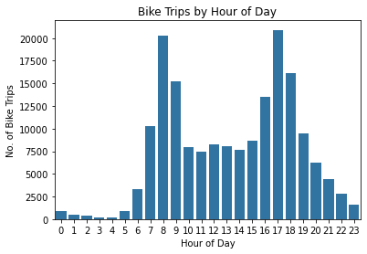

```python
# Ratings
sb.countplot(data=df_clean, x='start_time_hour', color = basic_color);
plt.title('Bike Trips by Hour of Day')
plt.xlabel('Hour of Day')
plt.ylabel('No. of Bike Trips')
```

Here we can see most of the bike trips occur in the morning and evening:

- Morning: 8:00 show's the most activity.
- Evening: 17:00 shows the most activity.

This could line up with people going to and coming home from work or school.

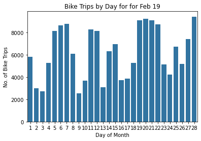

```python
sb.countplot(data=df_clean, x='start_time_day', color = basic_color);
plt.title('Bike Trips by Day for for Feb 19')
plt.xlabel('Day of Month')
plt.ylabel('No. of Bike Trips')
```

We see some spikes and on average there is more trips towards the end of the month than at the start.

- Most Trips: 28th
- Least Trips: 9th

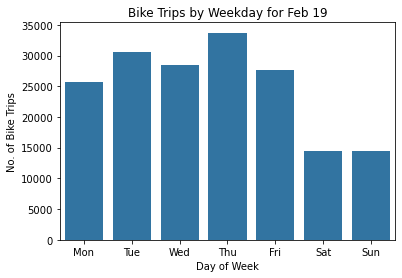

```python
sb.countplot(data=df_clean, x='start_time_weekday', color = basic_color, order=['Mon','Tue','Wed','Thu','Fri','Sat','Sun']);
plt.title('Bike Trips by Weekday for Feb 19')
plt.xlabel('Day of Week')
plt.ylabel('No. of Bike Trips')
```

Trips are more frequent during the week, again as noted earlier this could be due to trips to/from school or work.

- Most Trips: Thursday
- Least Trips: Saturday & Sunday are similiar.

```
(-1.1199361631365747,
 1.107706629514497,
 -1.1203835586186992,
 1.1072592340323726)
```

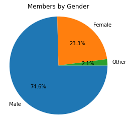

```python
# Ref for Pie Charts = https://matplotlib.org/3.1.1/gallery/pie_and_polar_charts/pie_features.html

sorted_counts = df_clean['member_gender'].value_counts()

plt.pie(sorted_counts, labels = sorted_counts.index, autopct='%1.1f%%', startangle = 0, counterclock = False);

plt.title("Members by Gender");

plt.axis('square')
```

The vast majority, 74.6%, of members are men.

```
(-1.1054688582560726,
 1.1090705094610591,
 -1.107227178965096,
 1.1073121887520356)
```

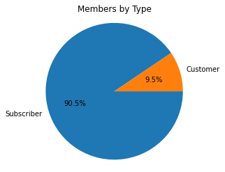

```python
sorted_counts = df_clean['user_type'].value_counts()

plt.pie(sorted_counts, labels = sorted_counts.index, autopct='%1.1f%%', startangle = 0, counterclock = False);

plt.title("Members by Type");

plt.axis('square')
```

Over 9 out of 10 (90.5%) members where subscribers.

```
(-1.104309013415037,
 1.1102012802921768,
 -1.1068950535821707,
 1.1076152401250432)
```

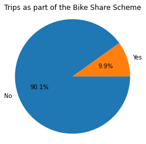

```python
sorted_counts = df_clean['bike_share_for_all_trip'].value_counts()

plt.pie(sorted_counts, labels = sorted_counts.index, autopct='%1.1f%%', startangle = 0, counterclock = False);

plt.title("Trips as part of the Bike Share Scheme");

plt.axis('square')
```

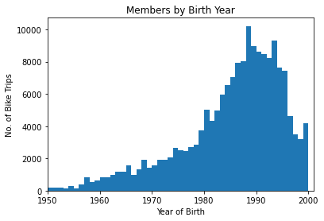

```python
# Just a rough look to get an idea of the general age of the members.
# We start the x axis at 1950 as those prior to this date are so small in volume that they add no value to the visual.

bins = np.arange(0, df_clean['member_birth_year'].max())
plt.hist(data = df_clean, x = 'member_birth_year', bins = bins)
plt.xlim((1950, 2001))

plt.title('Members by Birth Year')
plt.xlabel('Year of Birth')
plt.ylabel('No. of Bike Trips')
```

We see an increase over time indicating that, in general, younger users are the most common.

It seems most popular for those borth in the late 80's to the mid 90's.

```python
# create a new column for member_age.
df_clean['member_age'] = pd.Series(dtype='float64')
```

```python
# calculations for member_age
# data is from 2019 so we will subtract the birth year from this year.
df_clean.member_age = 2019 - df_clean.member_birth_year
```

```python
df_clean.member_age.describe()
```

```
count    174952.000000
mean         34.196865
std          10.118731
min          18.000000
25%          27.000000
50%          32.000000
75%          39.000000
max         141.000000
Name: member_age, dtype: float64
```

For our new Age column:

- Minimum: 18
- Maximum: 141 (There are a number of members with ages 100+, we'll clean these up as they are unlikely to be accurate).
- Mean: 34.2

```python
# Dropping the 72 entries for the Year of Birth's that stretch back to prior to 1920 to try and tidy up the data.
df_clean = df_clean[df_clean['member_birth_year'] > 1919]
```

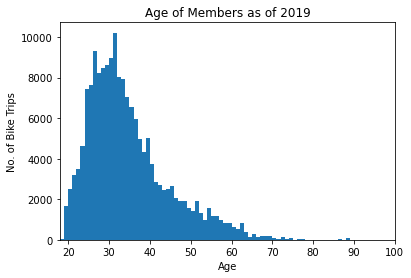

```python
# Overview of age

bins = np.arange(0, df_clean['member_age'].max())
plt.hist(data = df_clean, x = 'member_age', bins = bins)
plt.xlim((18, 100))

plt.title('Age of Members as of 2019')
plt.xlabel('Age')
plt.ylabel('No. of Bike Trips')
```

We see that that most members fall between being in their mid-20's and mid-30's.

The unusual maximum ages have been dropped off so the value will not go above 100.

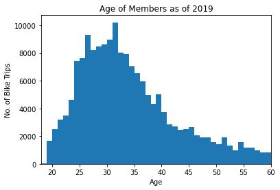

```python
# Overview with a closer look at the 18 to 60 range, where the majority of the data falls.

bins = np.arange(0, df_clean['member_age'].max())
plt.hist(data = df_clean, x = 'member_age', bins = bins)
plt.xlim((18, 60))

plt.title('Age of Members as of 2019')
plt.xlabel('Age')
plt.ylabel('No. of Bike Trips')
```

Just a magnified look at the above by restricting the age range to 18 - 60.

```python
# Looking at the description again after dropping the data.
df_clean.member_age.describe()
```

```
count    174880.000000
mean         34.162043
std           9.974001
min          18.000000
25%          27.000000
50%          32.000000
75%          39.000000
max          99.000000
Name: member_age, dtype: float64
```

For our cleaned Age column:

- Minimum: 18
- Maximum: 99 (I removed those that had a birth year of 1919 or previous).
- Mean: 34.2 (The amount of data we removed was insignificant enough that the mean was barely affected).

```python
df_clean['duration_min'] = pd.Series(dtype='int64')
```

```python
df_clean.duration_min = df_clean.duration_sec / 60
```

```python
df_clean.duration_min.describe()
```

```
count    174880.000000
mean         11.733706
std          27.375248
min           1.016667
25%           5.383333
50%           8.500000
75%          13.150000
max        1409.133333
Name: duration_min, dtype: float64
```

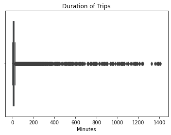

```python
sb.boxplot(x = df_clean.duration_min);
plt.xlabel('Minutes')
plt.title('Duration of Trips')
```

Here we can see the vast majority of the trips are near the 0 side of the axis.

After a manual review of the data I can see only 0.8% (1386 of 174880) are more than an hour long so we'll look at a snapshot of the duration of trips over the period of an hour.

```
(0.0, 60.0)
```

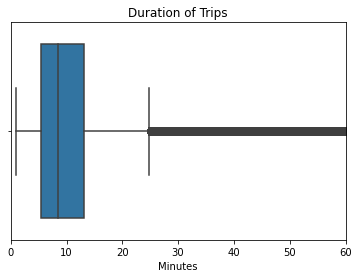

```python
sb.boxplot(x = df_clean.duration_min);
plt.xlabel('Minutes')
plt.title('Duration of Trips')

plt.xlim((0, 60))
```

We can see that the majority of the trips fell within the 5 to 13 minutes range.

- Min = 1.0
- Mean = 11.7
- Standard Deviation = 27.4
- 25% = 5.4
- 50% = 8.5
- 75% = 13.2

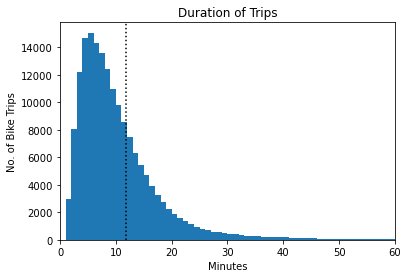

```python
bins = np.arange(0, df_clean['duration_min'].max())
plt.hist(data = df_clean, x = 'duration_min', bins = bins)
plt.xlim((0, 60))

# plt.axvline = https://stackoverflow.com/questions/24988448/how-to-draw-vertical-lines-on-a-given-plot-in-matplotlib
# line styles = https://matplotlib.org/stable/gallery/lines_bars_and_markers/linestyles.html

duration_min_mean=df_clean.duration_min.mean()
plt.axvline(duration_min_mean,label= 'Mean = '+str(round(duration_min_mean)) , linestyle = 'dotted', color='black')

plt.title('Duration of Trips')
plt.xlabel('Minutes')
plt.ylabel('No. of Bike Trips')
```

- Most members use the bikes for trips from approximately 5 to 13.
- The average trip length is approx 12 minutes.
- Relatively few members use the bikes for trips over 20 minutes long.

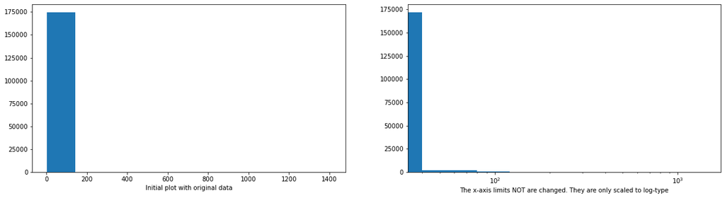

```python
# From lesson on Scales & Transformations

plt.figure(figsize = [20, 5])

# HISTOGRAM ON LEFT: full data without scaling
plt.subplot(1, 2, 1)
plt.hist(data=df_clean, x='duration_min');
# Display a label on the x-axis
plt.xlabel('Initial plot with original data')

# HISTOGRAM ON RIGHT
plt.subplot(1, 2, 2)

# Get the ticks for bins between [0 - maximum weight]
bins = np.arange(0, df_clean['duration_min'].max()+40, 40)
plt.hist(data=df_clean, x='duration_min', bins=bins);

# The argument in the xscale() represents the axis scale type to apply.
# The possible values are: {"linear", "log", "symlog", "logit", ...}
# Refer - https://matplotlib.org/3.1.1/api/_as_gen/matplotlib.pyplot.xscale.html
plt.xscale('log')
plt.xlabel('The x-axis limits NOT are changed. They are only scaled to log-type')
```

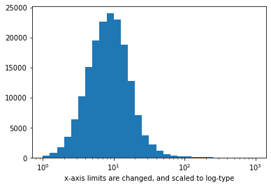

```python
# Axis transformation
# Bin size
bins = 10 ** np.arange(0, 3+0.1, 0.1)
plt.hist(data=df_clean, x='duration_min', bins=bins);

# The argument in the xscale() represents the axis scale type to apply.
# The possible values are: {"linear", "log", "symlog", "logit", ...}
plt.xscale('log')

# Apply x-axis label
# Documentatin: [matplotlib `xlabel`](https://matplotlib.org/api/_as_gen/matplotlib.pyplot.xlabel.html))
plt.xlabel('x-axis limits are changed, and scaled to log-type')
```

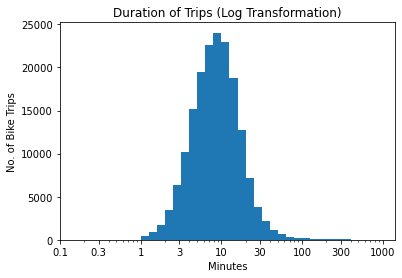

```python
# Get the ticks for bins between [0 - maximum weight]
bins = 10 ** np.arange(0, 3+0.1, 0.1)

# Generate the x-ticks you want to apply
ticks = [0.1, 0.3, 1, 3, 10, 30, 100, 300, 1000]
# Convert ticks into string values, to be displaye dlong the x-axis
labels = ['{}'.format(v) for v in ticks]

# Plot the histogram
plt.hist(data=df_clean, x='duration_min', bins=bins);

# The argument in the xscale() represents the axis scale type to apply.
# The possible values are: {"linear", "log", "symlog", "logit", ...}
plt.xscale('log')

# Apply x-ticks
plt.xticks(ticks, labels);

plt.title('Duration of Trips (Log Transformation)')
plt.xlabel('Minutes')
plt.ylabel('No. of Bike Trips')
```

The above 3 sets of visualisations is a transformation effort using scale transforamtions by applying a logarithmic transformation to the data.

This gives us a useful visual as this dataset has some odd outliers in the data.

- Max trip duration in minutes = 1409.133333
- Meanwhile the mean was only = 11.7

### Discuss the distribution(s) of your variable(s) of interest. Were there any unusual points? Did you need to perform any transformations?

- I applied a transformation to the trip duration as there where some oddities with the maximum values. This can be seen as the max trip duration was 1409.13 minutes which is only just over 1/2 hour less than a full day (24 hours).
- Applying the log scale transformation to the trip duration (in minutes) shows us a normal distribution curve, peaking at 10 minutes, which is far more useful visual.

### Of the features you investigated, were there any unusual distributions? Did you perform any operations on the data to tidy, adjust, or change the form of the data? If so, why did you do this?

- I broke the start_time down into additional columns for:
  - Hour of the Day
  - Day of the Month
  - Weekday
- Due to the unyieldy nature of using timings in seconds I transformed these figures into minutes which made them more manageable.
- For the Date of Births I found there were some odd years stretching back as far as 1878, I discared any dates further back than 1920.
  - Although it's still unlikely 100 year olds where regularly using the bike system I decided to remain cautious with my cut off date.

## Bivariate Exploration

Data I shall explore:

- Member numbers by gender & user type.
- Member ages by gender.
- Duration of trip by user type.
- No. of Bike Trips by Weekday & user_type.
- Inclusion in the Bike Share for All Program by User Group

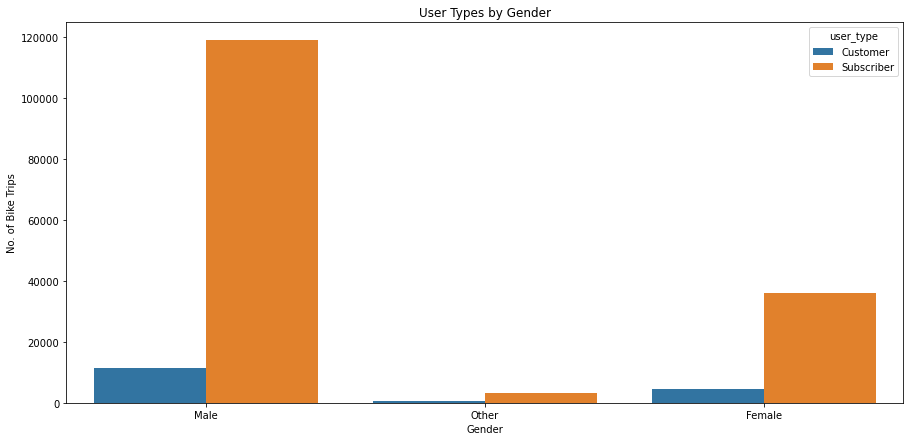

```python
plt.figure(figsize=(15, 7))
plt.title("User Type by Gender");
sb.countplot(data = df_clean, x = 'member_gender', hue = 'user_type');

plt.title('User Types by Gender')
plt.xlabel('Gender')
plt.ylabel('No. of Bike Trips')

plt.show()
```

- We already knew Male members where the majority.
  - The breakdown lets us see however that there is no real difference between genders, regardless of gender the users prefer to be subscribers if they're using the bike scheme.

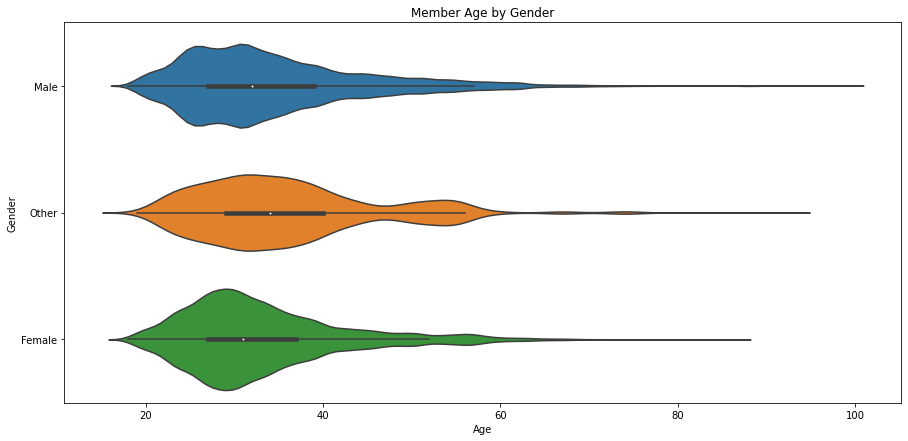

```python
# originally I had the member gender as the x axis but it was difficult to read so I switched them around.
# Question: Why is the graph in a box with side scroll?

plt.figure(figsize=(15, 7))
sb.violinplot(data = df_clean ,y='member_gender', x='member_age')

plt.title('Member Age by Gender')
plt.ylabel('Gender')
plt.xlabel('Age')

plt.show()
```

- We have seen it previously but we can see there is a number of members who prefer not to give their gender or who do not fall within the Male or Female category and, as such, may not be fairly recorded.
- Male members have a higher upper age than females.
- More male customers than female.

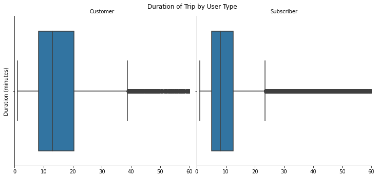

```python
# reference = https://seaborn.pydata.org/generated/seaborn.catplot.html

graph1 = sb.catplot(data = df_clean, x = 'duration_min', col = 'user_type', kind = 'box')

plt.xlim((0, 60))

# Reference material while I tried to fix labels and titles:
# Subtitles - https://stackoverflow.com/questions/55767312/how-to-position-suptitle
# and
# https://matplotlib.org/stable/api/_as_gen/matplotlib.pyplot.suptitle.html
graph1.fig.suptitle("Duration of Trip by User Type", y = 1)
graph1.set_axis_labels("", "Duration (minutes)")
graph1.set_titles("{col_name}");
```

Note: Again I am restricting the duration to 60 minutes to keep the visuals useful.

- From the above box plots we can see that, typically, a customer will go on longer trip's than a subscriber will.
- The mean & median are higher for the customers than for the subscribers.

This could indicate that customers are non-regular users so whilst subscribers would use the bikes for day-to-day activities so the average lengths would tend to be lower. Meanwhile the customers only use the bikes when planning an infrequent bike ride so it will be longer.

```python
df_clean.groupby("user_type")["duration_min"].mean()
```

```
user_type
Customer      21.846304
Subscriber    10.675875
Name: duration_min, dtype: float64
```

```python
df_clean.groupby("user_type")["duration_min"].median()
```

```
user_type
Customer      13.000000
Subscriber     8.166667
Name: duration_min, dtype: float64
```

The above proves that our box plots are showing that the differences between subscriber & customer correctly.

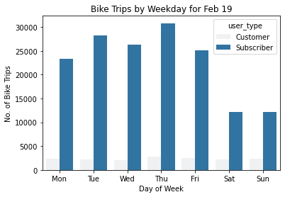

```python
sb.countplot(data=df_clean, x='start_time_weekday', hue = 'user_type',
             color = basic_color, order=['Mon','Tue','Wed','Thu','Fri','Sat','Sun']);
plt.title('Bike Trips by Weekday for Feb 19')
plt.xlabel('Day of Week')
plt.ylabel('No. of Bike Trips')
```

- Subscribers tend have greater number of bike trips throughout the work week.
- Customer bike trip numbers don't vary significantly between the various days.

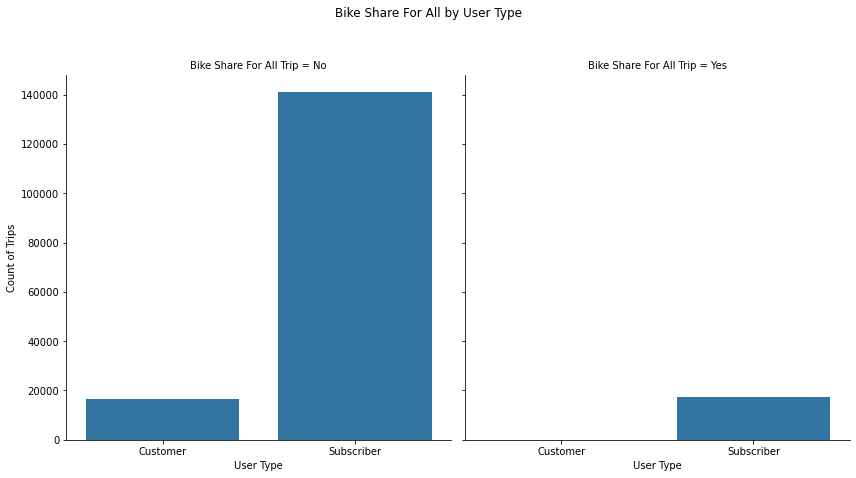

```python
graph2 = sb.catplot(data = df_clean, x = 'user_type', col = 'bike_share_for_all_trip', height = 6,
                   kind = 'count', color = basic_color)
graph2.fig.suptitle('Bike Share For All by User Type', y = '1.1')
graph2.set_axis_labels('User Type', 'Count of Trips')
graph2.set_titles('Bike Share For All Trip = ' + '{col_name}');
```

- Most of the users are Subscribers.
- Most subscribers are not part of the Bike Share For All program.
- No customers are part of the Bike Share for All Program

### Talk about some of the relationships you observed in this part of the investigation. How did the feature(s) of interest vary with other features in the dataset?

- By looking at trips by user type & gender together we where able to confirm that whilst men are, indeed, the most populus gender there is little difference between genders when it comes to preferring user type.
  - Male, Female & Other all where more likely to be subscribers than customers.
- Overall while there are more male members than female we where also able to confirm that men had a higher upper-age limit amongst members.
  - Female's had the lowest upper-age amongst members, even more so than the "other" category.
- We saw that by looking at trip duration along with user group the difference behaviours between the two.
  - Whilst we know already that customers are a far smaller group compared to subscribers we can now see that they tend to go on longer trips.
  - The average subscriber trip was only 10.7 minutes while the average customer's was over double that at 21.8.
  - This leads me to believe that customers are ad hoc users:
    - Subscribers likely use the bike for daily tasks, travelling to work and shopping etc.
    - Customers likely are users who require the trips for a sudden task or who simply want to go for a longer trip as a leisure activity. Some of these customers may not even be locals but visitors to San Francisco or tourists.
- Most users do not take part in the Bike Share for All program.
  - Those that do are made up of only Subscribers, no customers use this and may simply not be eligible.

### Did you observe any interesting relationships between the other features (not the main feature(s) of interest)?

- I didn't observe any interseting relationships outside the main features of interest described above.

## Multivariate Exploration

- Trips as part of the Bike Share program broken down by User Type alongside Gender.

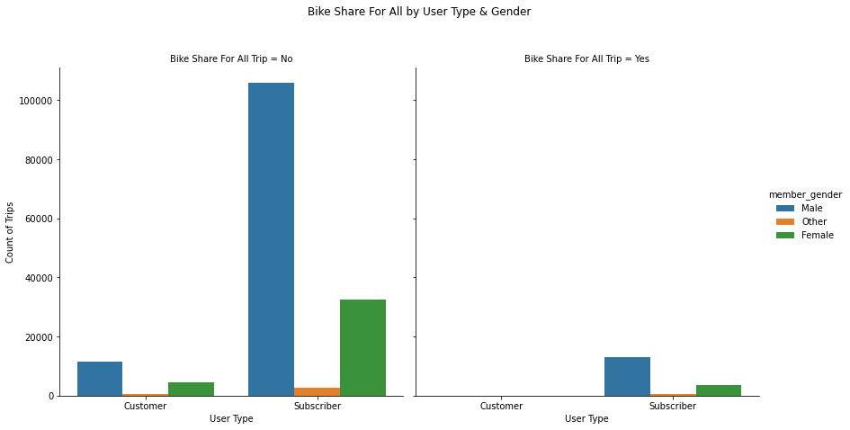

```python
graph3 = sb.catplot(data = df_clean, x = 'user_type', col = 'bike_share_for_all_trip', hue = 'member_gender',
                    height = 6, kind = 'count')
graph3.fig.suptitle('Bike Share For All by User Type & Gender', y = '1.1')
graph3.set_axis_labels('User Type', 'Count of Trips')
graph3.set_titles('Bike Share For All Trip = ' + '{col_name}');
```

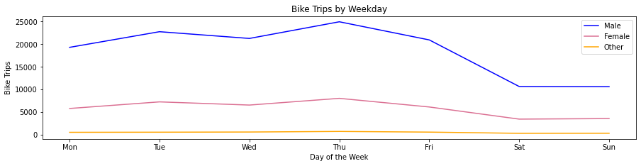

```python
# Reference for Day Order = https://stackoverflow.com/questions/47255746/change-order-on-x-axis-for-matplotlib-chart

# setting up params
fig = plt.figure(figsize = [15,7])
ax = plt.subplot(2, 1, 1)
day_order = ['Mon','Tue','Wed','Thu','Fri','Sat','Sun']

#plotting male data
df.groupby([df_clean[df_clean['member_gender']=='Male']['start_time_weekday']]).size().loc[day_order].plot(c='Blue', label='Male')

#plotting female data
df.groupby([df_clean[df_clean['member_gender']=='Female']['start_time_weekday']]).size().loc[day_order].plot(c='palevioletred', label='Female')

#plotting other data
df.groupby([df_clean[df_clean['member_gender']=='Other']['start_time_weekday']]).size().loc[day_order].plot(c='orange', label='Other')

plt.title("Bike Trips by Weekday")
plt.xlabel('Day of the Week')
plt.ylabel('Bike Trips')

plt.legend(loc='best')  # legend location = best
plt.show()
```

- Although the volume of Bike Trips varies massively between genders we can see that both are similar throughout the week.
  - For "Other" we don't see much of a trend however there is a much lower volume of these users so are too insignificant in volume to see trends for.
- Peaking at Thursday is the same for both genders while the weekend has the least amount of Bike Trips.

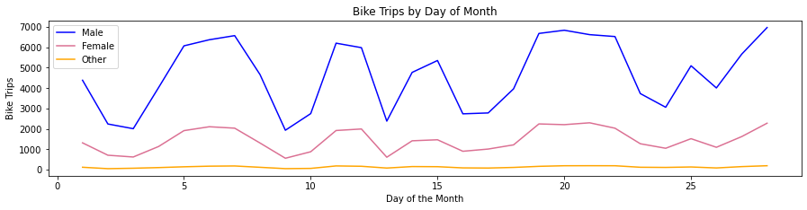

```python
# Reference for Day Order = https://stackoverflow.com/questions/47255746/change-order-on-x-axis-for-matplotlib-chart

# setting up params
fig = plt.figure(figsize = [15,7])
ax = plt.subplot(2, 1, 1)

#plotting male data
df_clean.groupby([df_clean[df_clean['member_gender']=='Male']['start_time_day']]).size().plot(c='Blue', label='Male')

#plotting female data
df_clean.groupby([df_clean[df_clean['member_gender']=='Female']['start_time_day']]).size().plot(c='palevioletred', label='Female')

#plotting other data
df_clean.groupby([df_clean[df_clean['member_gender']=='Other']['start_time_day']]).size().plot(c='orange', label='Other')

plt.title("Bike Trips by Day of Month")
plt.xlabel('Day of the Month')
plt.ylabel('Bike Trips')

plt.legend(loc='best')  # legend location = best
plt.show()
```

- Peaks and troughs are similar between men and women.
  - Weekends where on: 2 & 3, 9 & 10, 16 & 17 and 23 & 24.
    - Most of these troughs coincide with these dates, the other low points may simply be down to the likes of bad weather.
- Again other numbers are insignificant.

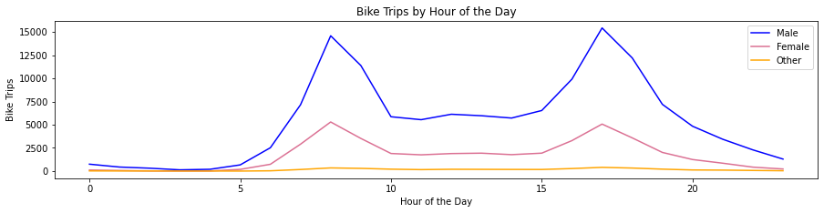

```python
# Reference for Day Order = https://stackoverflow.com/questions/47255746/change-order-on-x-axis-for-matplotlib-chart

# setting up params
fig = plt.figure(figsize = [15,7])
ax = plt.subplot(2, 1, 1)

#plotting male data
df_clean.groupby([df_clean[df_clean['member_gender']=='Male']['start_time_hour']]).size().plot(c='Blue', label='Male')

#plotting female data
df_clean.groupby([df_clean[df_clean['member_gender']=='Female']['start_time_hour']]).size().plot(c='palevioletred', label='Female')

#plotting other data
df_clean.groupby([df_clean[df_clean['member_gender']=='Other']['start_time_hour']]).size().plot(c='orange', label='Other')

plt.title("Bike Trips by Hour of the Day")
plt.xlabel('Hour of the Day')
plt.ylabel('Bike Trips')

plt.legend(loc='best')  # legend location = best
plt.show()
```

- We can see activity dropping off almost completely as we reach midnight and into the early hours of the morning.
- Peaks where at 8:00 & 17:00, likely due to commuting.
- Again Gender doesn't seem to be a big factor for peaks and troughs.
  - "Other" is too small a volume again of trips to show any significant data.

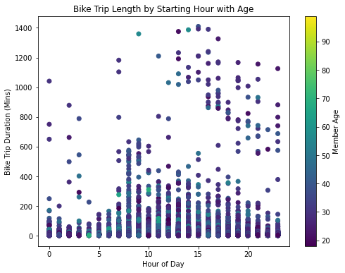

```python
plt.figure(figsize = [8,6])
plt.scatter(data = df_clean, x = 'start_time_hour', y = 'duration_min',
            c = 'member_age')
plt.colorbar(label = 'Member Age')
plt.xlabel('Hour of Day')
plt.ylabel('Bike Trip Duration (Mins)')
plt.title('Bike Trip Length by Starting Hour with Age')
```

```
(0.0, 120.0)
```

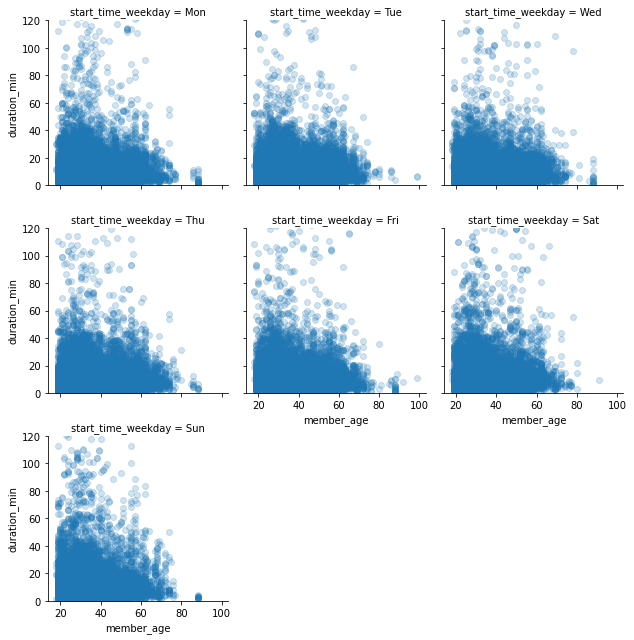

```python
# shown in the udacity lessons

week_days = ['Mon', 'Tue', 'Wed', 'Thu', 'Fri', 'Sat', 'Sun']
pd_ver = pd.__version__.split(".")
if (int(pd_ver[0]) > 0) or (int(pd_ver[1]) >= 21): # v0.21 or later
    weekdays = pd.api.types.CategoricalDtype(ordered = True, categories = week_days)
    df_clean['start_time_weekday'] = df_clean['start_time_weekday'].astype(weekdays)
else: # compatibility for v.20
    df_clean['start_time_weekday'] = df_clean['start_time_weekday'].astype('category', ordered = True,
                                                         categories = week_days)

# plotting
g = sb.FacetGrid(data = df_clean, col = 'start_time_weekday', size = 3, col_wrap = 3)
g.map(plt.scatter, 'member_age', 'duration_min', alpha = 1/5)
plt.ylim((0, 120))
```

- Each day the majority of trips are quite short, under an hour long.
- Trips by very elder individuals (80+) are uncommon no matter the day.
- The older the members the shorter and less common the trips are.

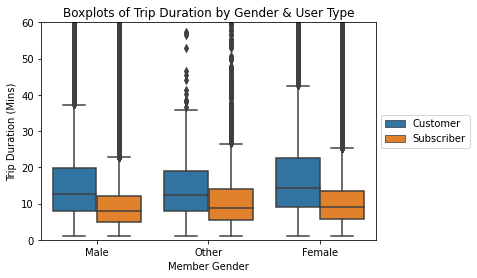

```python
week_days = ['Mon', 'Tue', 'Wed', 'Thu', 'Fri', 'Sat', 'Sun']
pd_ver = pd.__version__.split(".")
if (int(pd_ver[0]) > 0) or (int(pd_ver[1]) >= 21):
    weekdays = pd.api.types.CategoricalDtype(ordered = True, categories = week_days)
    df_clean['start_time_weekday'] = df_clean['start_time_weekday'].astype(weekdays)
else:
    fdf_clean['start_time_weekday'] = df_clean['start_time_weekday'].astype('category', ordered = True,
                                                         categories = week_days)

df_clean_sub = df_clean.loc[df_clean['user_type'].isin(['Customer', 'Subscriber'])]

# plotting
sb.boxplot(data = df_clean_sub, y = 'duration_min', x = 'member_gender', hue = 'user_type')
plt.legend(loc = 6, bbox_to_anchor = (1.0, 0.5)) # legend to right of figure
plt.ylim((0, 60))

plt.title('Boxplots of Trip Duration by Gender & User Type')
plt.ylabel('Trip Duration (Mins)')
plt.xlabel('Member Gender')
```

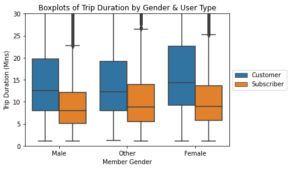

```python
week_days = ['Mon', 'Tue', 'Wed', 'Thu', 'Fri', 'Sat', 'Sun']
pd_ver = pd.__version__.split(".")
if (int(pd_ver[0]) > 0) or (int(pd_ver[1]) >= 21):
    weekdays = pd.api.types.CategoricalDtype(ordered = True, categories = week_days)
    df_clean['start_time_weekday'] = df_clean['start_time_weekday'].astype(weekdays)
else:
    fdf_clean['start_time_weekday'] = df_clean['start_time_weekday'].astype('category', ordered = True,
                                                         categories = week_days)

df_clean_sub = df_clean.loc[df_clean['user_type'].isin(['Customer', 'Subscriber'])]

# plotting
sb.boxplot(data = df_clean_sub, y = 'duration_min', x = 'member_gender', hue = 'user_type')
plt.legend(loc = 6, bbox_to_anchor = (1.0, 0.5)) # legend to right of figure
plt.ylim((0, 30))

plt.title('Boxplots of Trip Duration by Gender & User Type')
plt.ylabel('Trip Duration (Mins)')
plt.xlabel('Member Gender')
```

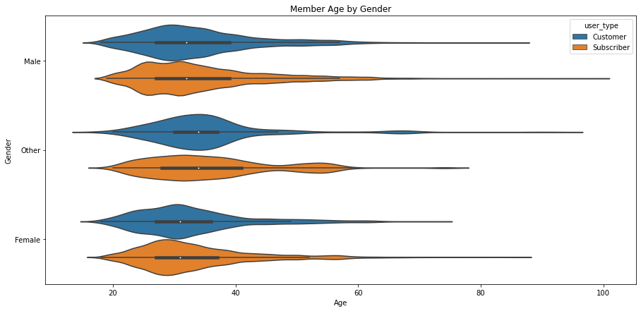

```python
# originally I had the member gender as the x axis but it was difficult to read so I switched them around.
# Question: Why is the graph in a box with side scroll?

plt.figure(figsize=(15, 7))
sb.violinplot(data = df_clean ,y='member_gender', x='member_age', hue = 'user_type')

plt.title('Member Age by Gender')
plt.ylabel('Gender')
plt.xlabel('Age')

plt.show()
```

### Were there any interesting or surprising interactions between features?

There was nothing overly unusual however the fact that there are members over the age of 80 actively taking part in the bike scheme, even after we tidied up the data, is a little shocking. In fact we see some at the 100 mark which is the maximum of the data after we cleaned it up.

## Some Overall Conclusions

#### Subscribers vs Customers

Consumers tend to take longer trips which seems to indicate that while Subscribers use the bikes for day to day commuting while consumers are using them for more ad hoc needs, likely including leisure or perhaps even visitors to the City.

#### Trips throughout the Day & Month

Day-to-Day the Customers don't tend to see much variance throughout the week. Meanwhile Subscribers use the bikes for trips mostly throughout the weeks with a significant drop-off during the weekend.

Throughout the month we see peaks and troughs however most of the drop-offs seem to coincide with the weekend which aligns with what we saw elsewhere. There are some other days where trips aren't common but we don't have enough data to say how, these could simply be days when the weather is too poor for going out on the bike.

Gender appears to be insignificant when it comes to Male & Female members throughout the weekday and month day data, with them sharing the same peaks and troughs but with Males being obviously more numerous due to the earlier mentioned difference in membership between the two genders.

#### Ages of Users

We also see that the majority of trips are undertaken by members in their 20's & 30's with the overall mean age of members being 34.

The elderly members tend to go on shorter trips.

```python
# Exporting the new dataset to a csv file
df_clean.to_csv("bike_data_clean.csv", index = False)
```